# Advanced Empirical Finance: Topics and Data Science

Estimation uncertainty

Stefan Voigt

University of Copenhagen and Danish Finance Institute (DFI)

Spring 2027

## Your tangency portfolios, out of sample

In exercise 2, you chose 10 to 30 stocks, estimated their tangency portfolio from 1990 to 1999, and kept the weights fixed from 2000 to 2009. In the lecture, we plot the two Sharpe ratios of every portfolio of the class

# Where the error comes from

## The plug-in principle

- Lecture 2 used $\hat\mu$ and $\hat\Sigma$ as if they were the true $\mu$ and $\Sigma$: the **plug-in** portfolio

$$\hat\omega = \omega(\hat\mu, \hat\Sigma) \qquad \text{instead of} \qquad \omega^* = \omega(\mu, \Sigma)$$

- $\hat\omega$ is an estimate, too: it has a sampling distribution
- On the Dow Jones stocks, the in-sample tangency portfolio promised a Sharpe ratio of 1.45 with 10 short positions

**Today:** how large is the estimation error, what does it cost, and what does a portfolio earn out of sample?

## Whiteboard: how precise is an expected return?

Monthly returns with mean $\mu$ and volatility $\sigma$, observed over $T$ months. What is the standard error of $\hat\mu$, annualized?

$$\text{SE}(\hat\mu_\text{annual}) = \frac{\sigma_\text{annual}}{\sqrt{\text{years}}}$$

- It depends on the **length** of the sample, not on how often we observe: daily data do not help (Merton, 1980). Variances, in contrast, get more precise with more frequent data
- A typical Dow Jones stock over 25.9 years: expected return 12.4%, volatility 25.7%, standard error **5.1%**. The 95% interval runs from 2.5% to 22.3%

## Errors in expected returns hurt most

- Small errors in $\hat\mu$ change the weights a lot; errors in variances and covariances matter much less (Chopra & Ziemba, 1993)
- The optimizer goes long the assets whose expected returns we overestimated and short the ones we underestimated: “error maximization” (Michaud, 1989)
- $\hat\Sigma^{-1}$ amplifies the errors, the more so the closer $N$ is to $T$: with 27 stocks, a 60-month window has barely two observations per stock
- The minimum-variance portfolio needs no $\hat\mu$ at all

## Whiteboard: what plug-in weights cost

With a risk-free asset, $\text{CE}(\omega) = \omega'\mu - \frac{\gamma}{2}\omega'\Sigma\omega$ for excess returns, so $\omega^* = \frac{1}{\gamma}\Sigma^{-1}\mu$. The plug-in investor holds $\hat\omega = \frac{1}{\gamma}\Sigma^{-1}\hat\mu$, with $\Sigma$ known and $\hat\mu$ from $T$ months. What is the expected loss in certainty equivalent?

$$\text{CE}(\omega^*) - E\big[\text{CE}(\hat\omega)\big] = \frac{\gamma}{2}E\big[(\hat\omega - \omega^*)'\Sigma(\hat\omega - \omega^*)\big] = \frac{N}{2\gamma T}
\qquad \text{CE}(\omega^*) = \frac{\theta^2}{2\gamma}$$

- $\theta^2 = \mu'\Sigma^{-1}\mu$ is the squared Sharpe ratio of the tangency portfolio. The plug-in portfolio is worse than the risk-free asset alone if $N/T > \theta^2$ (Kan & Zhou, 2007), and $\hat\Sigma$ makes it worse
- Dow Jones: $\theta^2 \approx$ 0.17 per month (in sample, so too high), but $N/T$ = 0.45 with a 60-month window

# Same truth, different samples

## The experiment

- Pretend we know the truth: $\mu_0$ and $\Sigma_0$ are the sample moments of the 27 Dow Jones stocks, 2000–2025
- Draw $T$ months of returns from $N(\mu_0, \Sigma_0)$, estimate $\hat\mu$ and $\hat\Sigma$, and compute the efficient frontier and the tangency portfolio
- Evaluate these **estimated** portfolios with the **true** $\mu_0$ and $\Sigma_0$: what would they really deliver?
- Repeat for many samples, with $T$ = 60 and 240 months

## Estimated portfolios, true outcomes

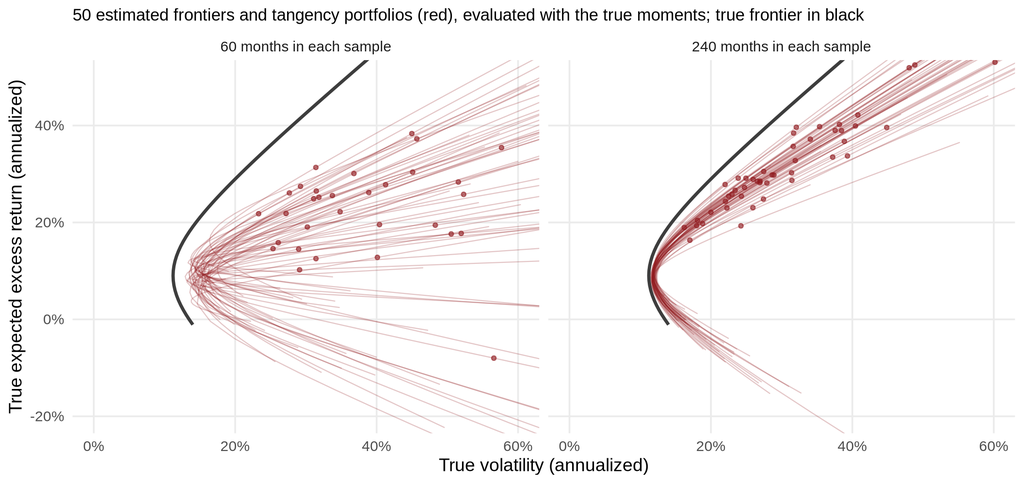

## What the plug-in tangency portfolio really earns

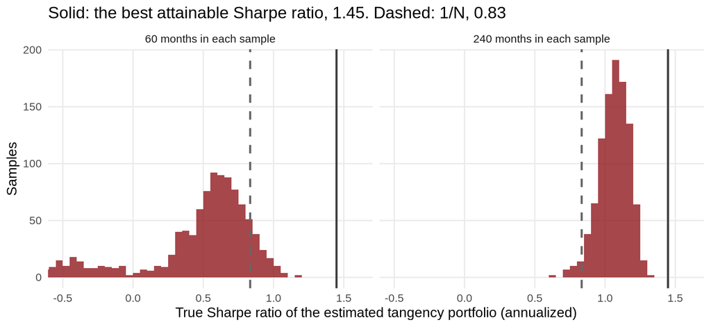

- With 60 months, 89% of the estimated tangency portfolios do worse than 1/N; with 240 months, 3%
- Caution: this truth is the in-sample view of today’s Dow Jones stocks, with a Sharpe ratio of 1.45. With realistic Sharpe ratios, the plug-in portfolio needs far longer samples

# Backtesting the Dow Jones

## Rolling windows

- Out of sample: at every month $t$, use only data an investor had at the time
- Estimate $\hat\mu_t$ and $\hat\Sigma_t$ from the last 60 months, form the weights $\hat\omega_t$, and earn $r_{p,t+1} = \hat\omega_t' r_{t+1}$ over the next month
- Roll one month ahead and repeat; compare strategies by their out-of-sample returns

[figure not shown]

## Four strategies

- **Plug-in tangency:** $\hat\omega_\text{tan} \propto \hat\Sigma^{-1}\hat\mu$, from excess returns
- **Plug-in minimum variance:** $\hat\omega_\text{mvp} \propto \hat\Sigma^{-1}\iota$, no expected returns
- **1/N:** every stock gets the same weight, nothing estimated
- **Minimum variance, no short sales:** no closed form, a quadratic program

$$\min_\omega \ \omega'\hat\Sigma\omega \quad \text{s.t.} \quad \iota'\omega = 1, \ \ \omega_i \geq 0$$

R: `solve.QP()` from quadprog. Python: `minimize()` from scipy

## Excess returns, month by month

- R
- Python

```r
risk_free <- read_parquet("data/factors_ff3_monthly.parquet") |>
  select(date, risk_free)

excess_wide <- returns_monthly |>
  left_join(risk_free, join_by(date)) |>
  mutate(ret_excess = ret - risk_free) |>
  pivot_wider(id_cols = date, names_from = symbol, values_from = ret_excess) |>
  arrange(date)
excess_matrix <- excess_wide |> select(-date) |> as.matrix()
n_stocks <- ncol(excess_matrix)

min_variance_no_short <- function(sigma) {
  solve.QP(
    Dmat = sigma, dvec = rep(0, n_stocks),
    Amat = cbind(1, diag(n_stocks)), bvec = c(1, rep(0, n_stocks)), meq = 1
  )$solution
}
```

```python
risk_free = pl.read_parquet("data/factors_ff3_monthly.parquet").select("date", "risk_free")

excess_wide = (
    returns_monthly.join(risk_free, on="date", how="left")
    .with_columns(ret_excess=pl.col("ret") - pl.col("risk_free"))
    .pivot(on="symbol", index="date", values="ret_excess")
    .sort("date")
)
excess_matrix = excess_wide.drop("date").to_numpy()
n_months, n_stocks = excess_matrix.shape
iota = np.ones(n_stocks)

def min_variance_no_short(sigma):
    return minimize(
        lambda w: w @ sigma @ w, x0=iota / n_stocks, jac=lambda w: 2 * sigma @ w,
        bounds=[(0, 1)] * n_stocks, method="SLSQP", options={"ftol": 1e-12},
        constraints={"type": "eq", "fun": lambda w: w.sum() - 1},
    ).x
```

## The backtest

- R
- Python

```r
backtest <- map(seq(window_length + 1, nrow(excess_matrix)), \(t) {
  window <- excess_matrix[(t - window_length):(t - 1), ]
  mu_hat <- colMeans(window)
  sigma_hat <- cov(window)
  sigma_inv <- solve(sigma_hat)
  returns_next <- excess_matrix[t, ]
  weights <- list(
    "Plug-in tangency" = as.vector(sigma_inv %*% mu_hat) / sum(sigma_inv %*% mu_hat),
    "Plug-in minimum variance" = rowSums(sigma_inv) / sum(sigma_inv),
    "1/N" = rep(1 / n_stocks, n_stocks),
    "Minimum variance, no short sales" = min_variance_no_short(sigma_hat)
  )
  tibble(
    date = excess_wide$date[t], strategy = names(weights), weights = weights,
    ret_excess = map_dbl(weights, \(w) sum(w * returns_next))
  )
}) |>
  bind_rows()
```

```python
records = []
for t in range(window_length, n_months):
    window = excess_matrix[t - window_length:t]
    mu_hat = window.mean(axis=0)
    sigma_hat = np.cov(window, rowvar=False)
    sigma_inv = np.linalg.inv(sigma_hat)
    weights = {
        "Plug-in tangency": sigma_inv @ mu_hat / (iota @ sigma_inv @ mu_hat),
        "Plug-in minimum variance": sigma_inv @ iota / (iota @ sigma_inv @ iota),
        "1/N": iota / n_stocks,
        "Minimum variance, no short sales": min_variance_no_short(sigma_hat),
    }
    for strategy, w in weights.items():
        records.append({"date": excess_wide["date"][t], "strategy": strategy,
                        "ret_excess": w @ excess_matrix[t]})
backtest = pl.DataFrame(records)
```

## Out of sample, February 2005 to December 2025

| Strategy | Excess return | Volatility | Sharpe ratio | Turnover per month |
| --- | --- | --- | --- | --- |
| 1/N | 14.3% | 14.9% | 0.96 | 4% |
| Minimum variance, no short sales | 10.7% | 12.4% | 0.86 | 15% |
| Plug-in minimum variance | 12.4% | 15.8% | 0.78 | 60% |
| Plug-in tangency | -1,986.4% | 8,989.6% | -0.22 | 5,824% |

- Annualized, excess returns over the T-bill rate. Turnover: the sum of absolute weight changes at each rebalancing
- 1/N, with nothing estimated, has the highest Sharpe ratio; the plug-in tangency portfolio is not investable

## Why the plug-in tangency portfolio fails

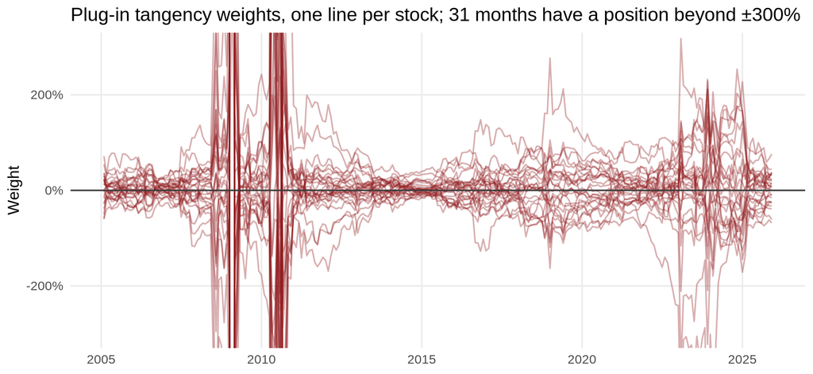

$\hat\omega_\text{tan}$ divides by $\iota'\hat\Sigma^{-1}\hat\mu$. When the estimated expected returns are close to zero on average, this sum is close to zero and the weights explode

## Cumulative excess returns

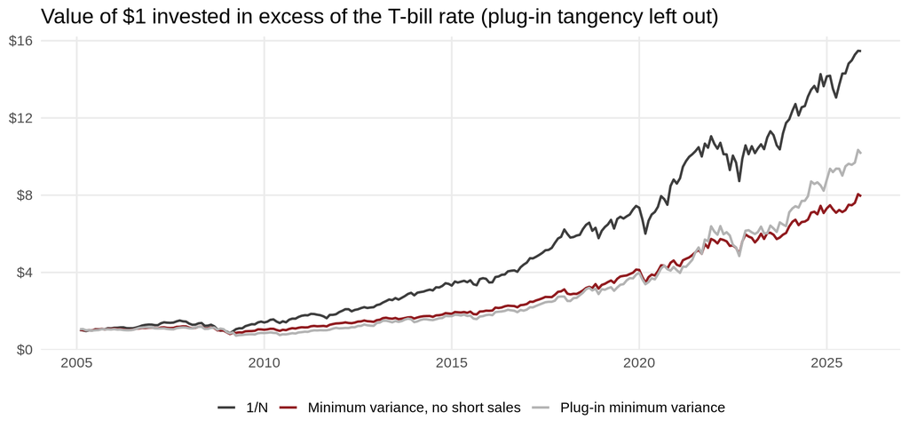

## What could go wrong in a backtest?

In the lecture, you collect examples: which information does a backtest use that an investor did not have at the time?

## Look-ahead bias and other traps

- **Survivorship:** our running example is guilty. We picked **today’s** Dow Jones stocks; in 2000, nobody knew which firms would be in the index in 2025. Firms that failed or left the index are missing (CRSP keeps them, with their delisting returns)
- **Data that did not exist yet:** annual reports appear months after the fiscal year ends; macro data and even the Fama-French factors are revised later; index memberships change
- **Timing:** weights formed with the returns of month $t$ must not earn the return of month $t$; a signal from today’s close cannot trade at today’s close
- **Full-sample choices:** standardizing with full-sample moments, or picking the window length, the risk aversion or the model after seeing the whole sample
- **Many tries, one report:** test enough strategies and one of them looks great by chance (more with portfolio sorts and reproducibility)
- **Frictions:** no transaction costs, free short sales and leverage (more with transaction costs)

# Optimal versus naive diversification

## DeMiguel, Garlappi & Uppal (2009)

- 14 models of optimal portfolio choice against 1/N, on seven empirical datasets
- None of them beats 1/N consistently out of sample, in Sharpe ratio, certainty equivalent or turnover
- With parameters calibrated to the US stock market, the sample-based mean-variance portfolio needs an estimation window of about **3,000 months** to beat 1/N with 25 assets, and about 6,000 months with 50 assets

**Discussion:** Is 1/N naive? What information does it use? When would you still optimize?

## What helps?

- **Ignore the expected returns:** the minimum-variance portfolio estimates only $\Sigma$
- **Constrain the weights:** no short sales stabilize the portfolio. Next lecture shows why: constraints act like shrinkage (Jagannathan & Ma, 2003)
- **Combine:** a mix of the plug-in portfolio and 1/N (Kan & Zhou, 2007)
- **Shrink the estimates:** Ledoit-Wolf for $\hat\Sigma$, Bayes-Stein for $\hat\mu$: next lecture

Your trading game portfolio is an estimated portfolio, too